# Reproducible Research Peer Graded Assignment: Course Project 2

Huseyin Emre Balli

December 15, 2018

# Most Harmful Events to the Population Health and to the General Economics

## Synopsis

This analysis is conducted for Coursera course Reproducible Research. Data set used for this analysis can be found in: https://d396qusza40orc.cloudfront.net/repdata%2Fdata%2FStormData.csv.bz2. Which is National Weather Service’s Storm Data. There are 2 main parts, in the first one analysis tries to determine which events are most harmful to the population health with using fatalities and injuries variables. And in the second part this analysis shows most harmful event types to the general economics with using property damage and crop damage variables.

## Data Processing

### Downloading and Reading Data

```r
file_url <- "https://d396qusza40orc.cloudfront.net/repdata%2Fdata%2FStormData.csv.bz2"
file_path <- "stormdata.csv.bz2"
download.file(file_url, file_path, method = "curl")
stormdata <- read.csv(file_path, stringsAsFactors = FALSE)
```

### Look for Basic Characteristics of the Dataset

```r
head(stormdata)
```

```
##   STATE__           BGN_DATE BGN_TIME TIME_ZONE COUNTY COUNTYNAME STATE
## 1       1  4/18/1950 0:00:00     0130       CST     97     MOBILE    AL
## 2       1  4/18/1950 0:00:00     0145       CST      3    BALDWIN    AL
## 3       1  2/20/1951 0:00:00     1600       CST     57    FAYETTE    AL
## 4       1   6/8/1951 0:00:00     0900       CST     89    MADISON    AL
## 5       1 11/15/1951 0:00:00     1500       CST     43    CULLMAN    AL
## 6       1 11/15/1951 0:00:00     2000       CST     77 LAUDERDALE    AL
##    EVTYPE BGN_RANGE BGN_AZI BGN_LOCATI END_DATE END_TIME COUNTY_END
## 1 TORNADO         0                                               0
## 2 TORNADO         0                                               0
## 3 TORNADO         0                                               0
## 4 TORNADO         0                                               0
## 5 TORNADO         0                                               0
## 6 TORNADO         0                                               0
##   COUNTYENDN END_RANGE END_AZI END_LOCATI LENGTH WIDTH F MAG FATALITIES
```

[output cut: 20 more lines]

```r
summary(stormdata)
```

```
##     STATE__       BGN_DATE           BGN_TIME          TIME_ZONE
##  Min.   : 1.0   Length:902297      Length:902297      Length:902297
##  1st Qu.:19.0   Class :character   Class :character   Class :character
##  Median :30.0   Mode  :character   Mode  :character   Mode  :character
##  Mean   :31.2
##  3rd Qu.:45.0
##  Max.   :95.0
##
##      COUNTY       COUNTYNAME           STATE              EVTYPE
##  Min.   :  0.0   Length:902297      Length:902297      Length:902297
##  1st Qu.: 31.0   Class :character   Class :character   Class :character
##  Median : 75.0   Mode  :character   Mode  :character   Mode  :character
##  Mean   :100.6
##  3rd Qu.:131.0
##  Max.   :873.0
##
##    BGN_RANGE          BGN_AZI           BGN_LOCATI
##  Min.   :   0.000   Length:902297      Length:902297
##  1st Qu.:   0.000   Class :character   Class :character
##  Median :   0.000   Mode  :character   Mode  :character
##  Mean   :   1.484
##  3rd Qu.:   1.000
##  Max.   :3749.000
##
##    END_DATE           END_TIME           COUNTY_END COUNTYENDN
##  Length:902297      Length:902297      Min.   :0    Mode:logical
##  Class :character   Class :character   1st Qu.:0    NA's:902297
##  Mode  :character   Mode  :character   Median :0
##                                        Mean   :0
##                                        3rd Qu.:0
##                                        Max.   :0
##
##    END_RANGE          END_AZI           END_LOCATI
##  Min.   :  0.0000   Length:902297      Length:902297
##  1st Qu.:  0.0000   Class :character   Class :character
##  Median :  0.0000   Mode  :character   Mode  :character
##  Mean   :  0.9862
##  3rd Qu.:  0.0000
##  Max.   :925.0000
##
```

[output cut: 33 more lines]

```
##  Min.   :-14451   Min.   :   0   Min.   :-14455   Length:902297
##  1st Qu.:  7247   1st Qu.:   0   1st Qu.:     0   Class :character
##  Median :  8707   Median :   0   Median :     0   Mode  :character
##  Mean   :  6940   Mean   :1452   Mean   :  3509
##  3rd Qu.:  9605   3rd Qu.:3549   3rd Qu.:  8735
##  Max.   : 17124   Max.   :9706   Max.   :106220
##                   NA's   :40
##      REFNUM
##  Min.   :     1
##  1st Qu.:225575
##  Median :451149
##  Mean   :451149
##  3rd Qu.:676723
##  Max.   :902297
##
```

```r
str(stormdata)
```

```
## 'data.frame':    902297 obs. of  37 variables:
##  $ STATE__   : num  1 1 1 1 1 1 1 1 1 1 ...
##  $ BGN_DATE  : chr  "4/18/1950 0:00:00" "4/18/1950 0:00:00" "2/20/1951 0:00:00" "6/8/1951 0:00:00" ...
##  $ BGN_TIME  : chr  "0130" "0145" "1600" "0900" ...
##  $ TIME_ZONE : chr  "CST" "CST" "CST" "CST" ...
##  $ COUNTY    : num  97 3 57 89 43 77 9 123 125 57 ...
##  $ COUNTYNAME: chr  "MOBILE" "BALDWIN" "FAYETTE" "MADISON" ...
##  $ STATE     : chr  "AL" "AL" "AL" "AL" ...
##  $ EVTYPE    : chr  "TORNADO" "TORNADO" "TORNADO" "TORNADO" ...
##  $ BGN_RANGE : num  0 0 0 0 0 0 0 0 0 0 ...
##  $ BGN_AZI   : chr  "" "" "" "" ...
##  $ BGN_LOCATI: chr  "" "" "" "" ...
##  $ END_DATE  : chr  "" "" "" "" ...
##  $ END_TIME  : chr  "" "" "" "" ...
##  $ COUNTY_END: num  0 0 0 0 0 0 0 0 0 0 ...
```

[output cut: 23 more lines]

### Data for Part - I

Create ‘harmful_health’ data frame with necessary variables. Add them up, summarise and order by most harmful. Then select top 6 event types to demonstrate most harmful one is “Tornado”.

```r
library(dplyr)
harmful_health <- stormdata %>%
        select(EVTYPE, FATALITIES, INJURIES)

harmful_health$EVTYPE <- as.factor(harmful_health$EVTYPE)

harmful_health$FatalorInjury <- harmful_health$FATALITIES + harmful_health$INJURIES

harmful_health <- harmful_health %>%
        select(EVTYPE, FatalorInjury)

harmful_health_summary <- harmful_health %>%
        group_by(EVTYPE) %>%
                summarise(Harm = sum(FatalorInjury)) %>%
                        arrange(desc(Harm))

harmful_health_summary_head <- head(harmful_health_summary)
```

### Data for Part - II

Create ‘harmful_econ’ data frame with necessary variables. Make sure that the variables is in same units, add them up, summarise and order by most harmful. Then select top 6 event types to demonstrate most harmful one is “Hail”.

```r
harmful_econ <- stormdata %>%
        select(EVTYPE, PROPDMG, PROPDMGEXP, CROPDMG, CROPDMGEXP)

harmful_econ$EVTYPE <- as.factor(harmful_econ$EVTYPE)

harmful_econ <- harmful_econ %>%
        filter(!(PROPDMG == 0 & CROPDMG == 0)) %>%
                mutate(Harm = ifelse(PROPDMG == 0,
                                     ifelse(CROPDMGEXP == "K",
                                            CROPDMG * 1000,
                                            ifelse(CROPDMGEXP == "M",
                                                   CROPDMG * 1000000,
                                                   ifelse(CROPDMGEXP == "B",
                                                          CROPDMG * 1000000000,
                                                          0))),
                                     ifelse(CROPDMG == 0,
                                            ifelse(PROPDMGEXP == "K",
                                                   PROPDMG * 1000,
                                                   ifelse(PROPDMGEXP == "M",
                                                          PROPDMG * 1000000,
                                                          ifelse(PROPDMGEXP == "B",
                                                                 PROPDMG * 1000000000,
                                                                 0))),
                                            ifelse(CROPDMGEXP == "K",
                                                   ifelse(PROPDMGEXP == "K",
                                                          CROPDMG * 1000 + PROPDMG * 1000,
                                                          ifelse(PROPDMGEXP == "M",
                                                                 CROPDMG * 1000 + PROPDMG * 1000000,
                                                                 CROPDMG * 1000 + PROPDMG * 1000000000)),
                                                   ifelse(CROPDMGEXP == "M",
                                                          ifelse(PROPDMGEXP == "K",
                                                                 CROPDMG * 1000000 + PROPDMG * 1000,
                                                                 ifelse(PROPDMGEXP == "M",
                                                                        CROPDMG * 1000000 + PROPDMG * 1000000,
                                                                        CROPDMG * 1000000 + PROPDMG * 1000000000)),
                                                          ifelse(PROPDMGEXP == "K",
                                                                 CROPDMG * 1000000000 + PROPDMG * 1000,
                                                                 ifelse(PROPDMGEXP == "M",
                                                                        CROPDMG * 1000000000 + PROPDMG * 1000000,
                                                                        CROPDMG * 1000000000 + PROPDMG * 1000000000)))))))

harmful_econ_summary <- harmful_econ %>%
        select(EVTYPE, Harm) %>%
                group_by(EVTYPE) %>%
                        summarise(Harm = sum(Harm)) %>%
                                arrange(desc(Harm))

harmful_econ_summary_head <- head(harmful_econ_summary)

harmful_econ_summary_head$Harm <- harmful_econ_summary_head$Harm / 1000000000
```

## Results

### Most Harmful Event Type for Healt is Tornado

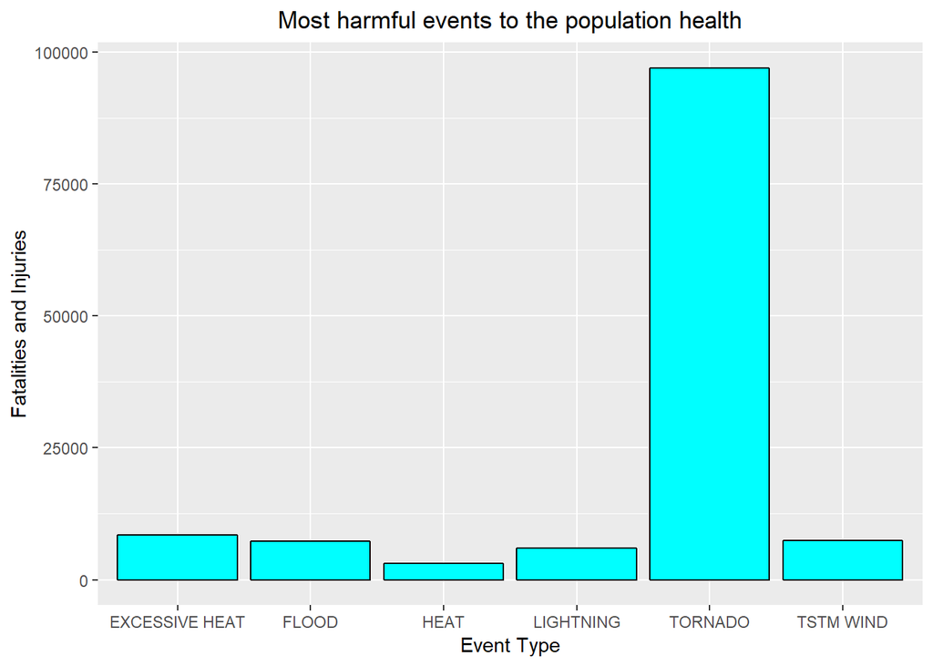

```r
library(ggplot2)
ggplot(data = harmful_health_summary_head, aes(x = EVTYPE, y = Harm)) +
        geom_col(fill = "cyan", color = "black") +
                labs(x = "Event Type", y = "Fatalities and Injuries", title = "Most harmful events to the population health") +
                        theme(plot.title = element_text(hjust = 0.5))
```

### Most harmful Event Type for Economics is Hail

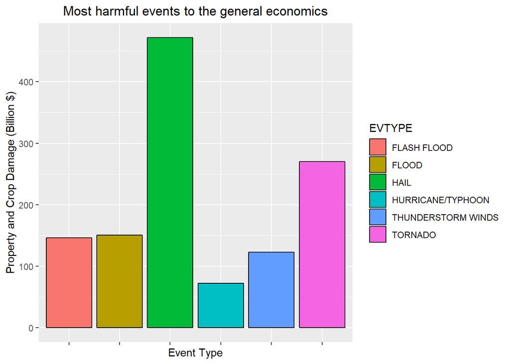

```r
ggplot(data = harmful_econ_summary_head, aes(x = EVTYPE, y = Harm)) +
        geom_col(aes(fill = EVTYPE), color = "black") +
                labs(x = "Event Type", y = "Property and Crop Damage (Billion $)", title = "Most harmful events to the general economics") +
                        theme(plot.title = element_text(hjust = 0.5), axis.text.x = element_blank())
```